# ggplot2

Por simplicidade, vamos avançar especificando o conjunto de dados dentro do `geom` e criando um objeto chamado `figura`. Vamos também fazer com que as cores dos símbolos sejam representadas pelos continentes, e modificar o formato dos pontos para que eles possam ser preenchidos.

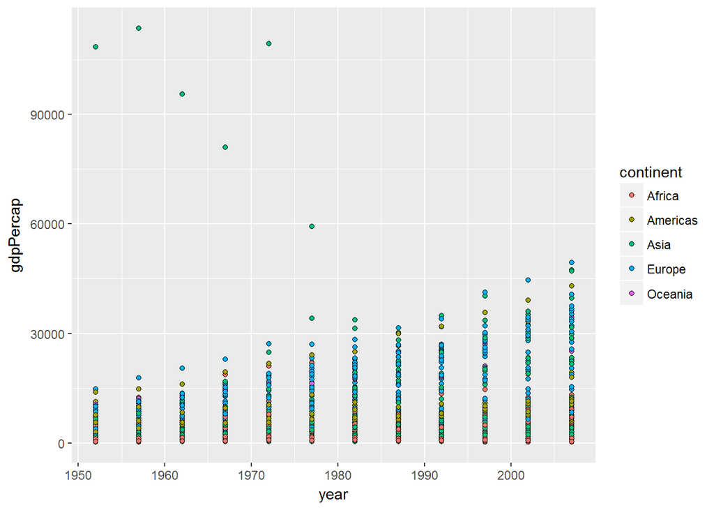

```r
figura <- ggplot() +
  geom_point(data = gapminder, mapping = aes(x = year, y = gdpPercap, fill = continent), shape = 21)
figura
```

O `fill` e o `shape` são elementos que modificam o preenchimento e o formato dos pontos na figura. Além deles, podemos especificar os argumentos `size`, `colour`, `alpha` e `stroke`.

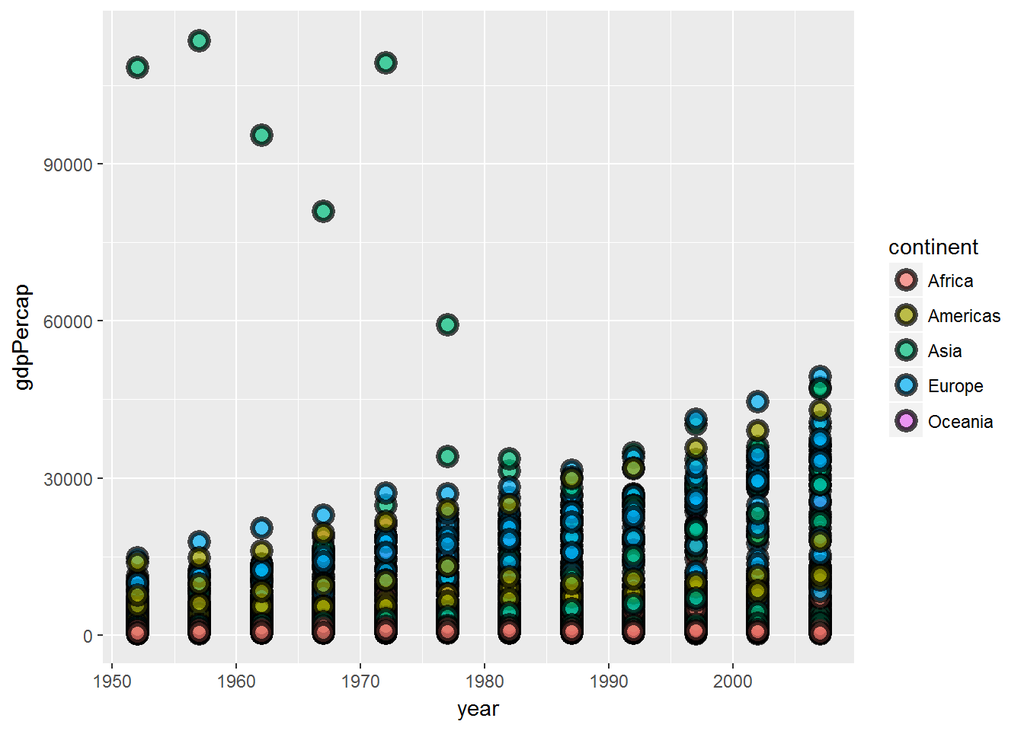

```r
figura <- ggplot() +
  geom_point(data = gapminder, mapping = aes(x = year, y = gdpPercap, fill = continent),
             shape = 21, colour = "black", size = 3, stroke = 2, alpha = 0.7)
figura
```

##### Exercício 2

1. O que cada um destes argumentos faz?
2. O que aconteceria se mapeássemos alguma variável categórica (como o continente) sob o cada um deles fora do mapping?
3. E se fizéssemos a mesma coisa dentro do parenteses?
4. O que acontece se mapearmos variáveis contínuas para eles?

Você pode não ter gostado do jogo de cores, ou ter criado um gráfico com certos `shape` ou `colour` e não ter curtido o padrão do `ggplot`. Nesse caso, você pode editar manualmente este jogo ou definir algum padrão pré-estabelecido com as funções `scale_*_?`. Note que você só conseguirá editar manualmente estas opções **se** elas tiverem sido mapeadas dentro de um `geom` ou na função `ggplot`.

- `scale_fill_?`: modifica o preenchimento do objeto (`fill`) de forma determinada pelo usuário;
- `scale_colour_?`: modifica a cor dos pontos ou das bordas do objeto geométrico (`colour`) de forma determinada pelo usuário;
- `scale_shape_?`: modifica o formato dos pontos (`shape`) de forma determinada pelo usuário;
- `scale_size_?`: modifica o tamanho dos pontos (`size`) de forma determinada pelo usuário;
- `scale_alpha_?`: modifica a transparência (`alpha`) de forma determinada pelo usuário;
- `scale_linetype_?`: modifica o tipo de linha (`linetype`) de forma determinada pelo usuário;
- `scale_x_?`: modifica as opções de apresentação do eixo *x*;
- `scale_y_?`: modifica as opções de apresentação do eixo *y*.

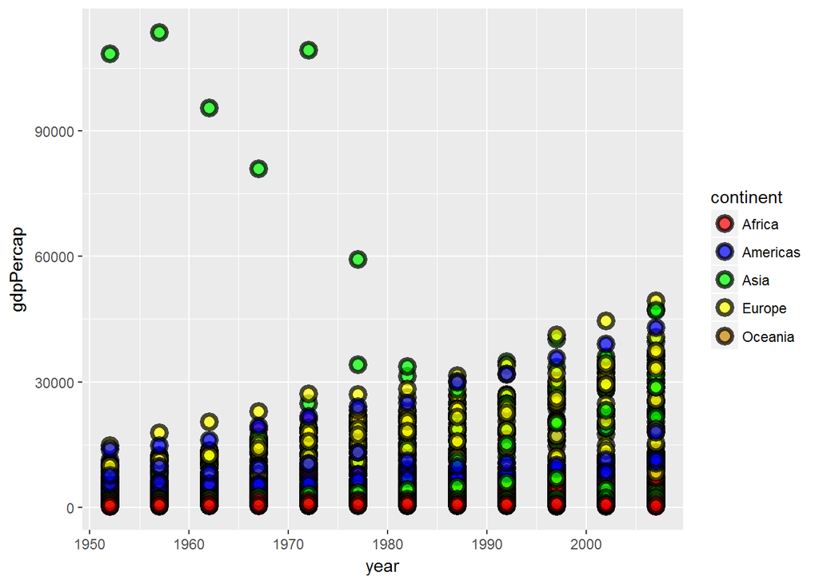

```r
# fornecendo um vetor de cores manualmente
figura +
  scale_fill_manual(values = c("red", "blue", "green", "yellow", "orange3"))
```

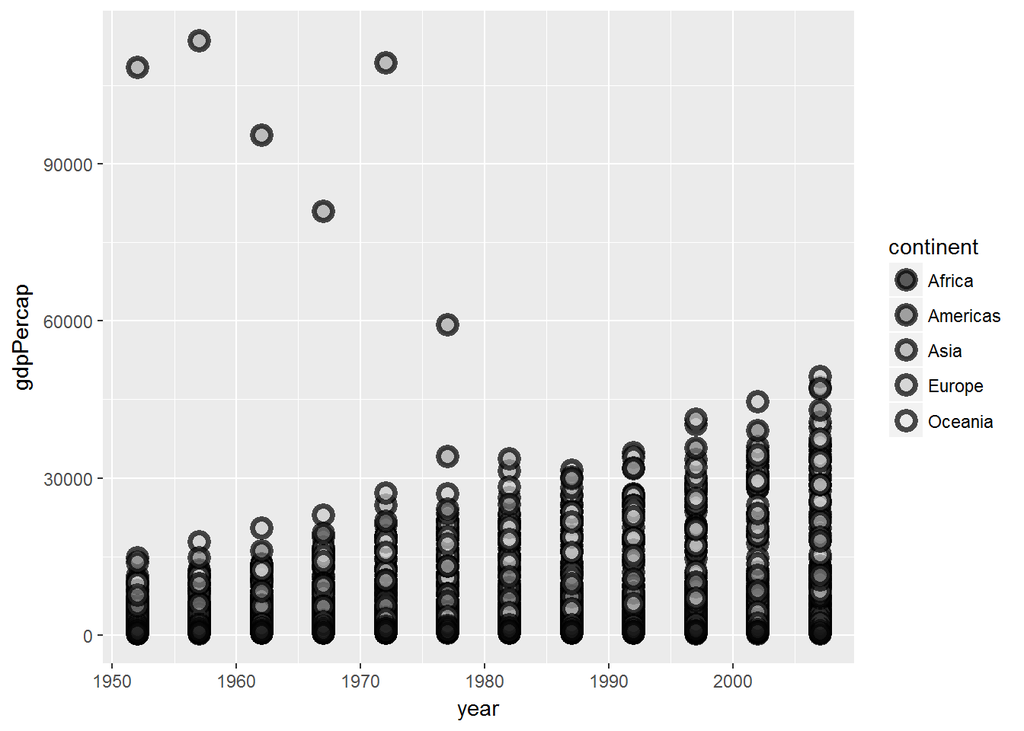

```r
# fornecendo um vetor de cores em um gradiente de cinza
figura +
  scale_fill_grey(start = 0.1, end = 0.9)
```

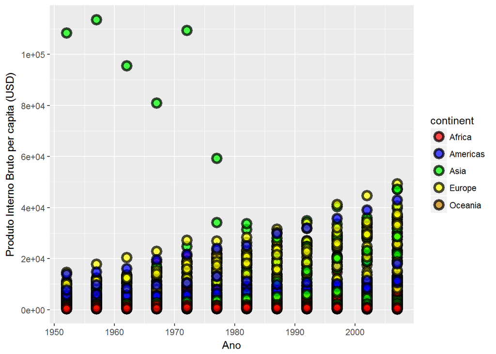

```r
# fornecendo um vetor de cores manualmente, editando os eixos x e y
figura <- figura +
  scale_fill_manual(values = c("red", "blue", "green", "yellow", "orange3")) +
  scale_x_continuous(name = "Ano") +
  scale_y_continuous(name = "Produto Interno Bruto per capita (USD)",
                     breaks = seq(from = 0, to = 120000, by = 20000))
figura
```

Além disso, podemos ainda criar diferentes painéis para plotarmos cada gráfico de acordo com as categorias de um fator.

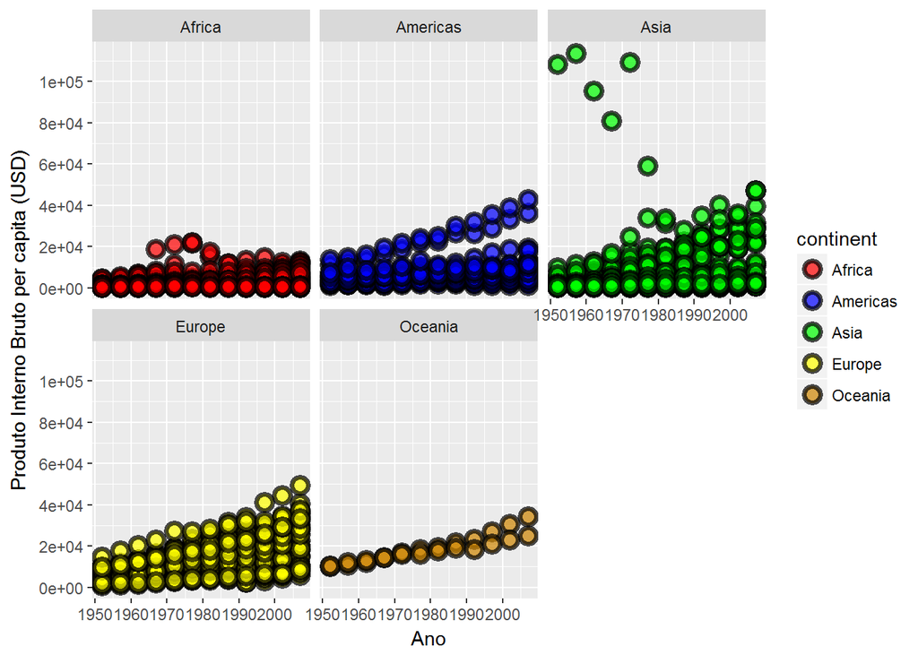

```r
figura +
  facet_wrap(facets = ~ continent)
```

Uma outra opção para tal é a função `facet_grid`:

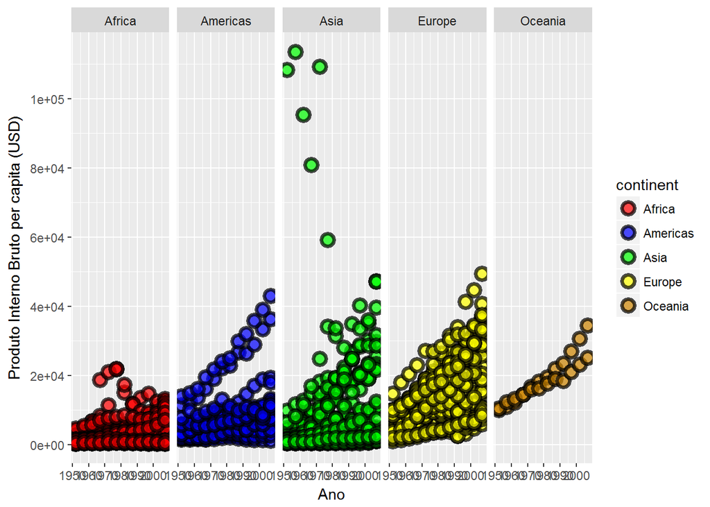

```r
figura +
  facet_grid(facets = ~ continent)
```

- **Dica do R:** diferenças entre estas duas formas de produzir estes múltiplos painéis:
  - `facet_wrap` é útil ao criarmos painéis de acordo com os níveis de uma variável, enquanto o `facet_grid` funciona com duas ou mais variáveis.
  - `facet_wrap` permite que você determine o número de linhas e colunas no painel, enquanto o `facet_grid` vai arranjar o número de linhas e colunas de acordo os níveis das variáveis mapeadas para estes painéis.

##### Exercício 3

Usando o conjunto de dados `mtcars`:

1. Qual a relação entre o consumo de combustível (`mpg`) e a potência dos carros (`hp`)?
2. Como esta relação varia em função do número de cilindros do carro (`cyl`)?
3. Como podemos visualizar esta relação de acordo com o número de cilindros e o tipo de transmissão do carro (`am`)?

Cabe ressaltar aqui que caso você precise criar uma figura em múltiplos painéis, talvez seja melhor separar os dados em `data.frame` diferentes e criar figuras individualmente. Um motivo para isso é que é muito, mas muito difícil, manipular cada um dos painéis individualmente no `facet_wrap` ou `facet_grid`.

Outra razão para separar os gráficos é que muitas vezes essas figuras em múltiplas painéis dizem respeito a figuras com diferentes escalas no eixo x e/ou y e/ou diferentes variáveis nos eixos x e y. Como vimos, existem várias funções no `dplyr` e `tidyr` que nos permitem fazer isso, e existem funções associadas ao `ggplot` que podem ser usadas para identificar os painéis e combiná-los posteriormente, mas não avançaremos sobre elas aqui.

Como vimos, um `geom` pode ser compreendido como um tipo de gráfico a ser plotado: um `boxplot`, um `scatterplot`, um gráfico de barras, um histograma, uma regressão e por aí vai. No entanto, algumas figuras precisam ser compostas por mais de um `geom`: e.g., uma regressão, onde temos tanto os pontos, quanto a linha de tendência da relação. Assim, o `ggplot` também nos dá a opção e flexibilidade de plotarmos dois `geom` em uma mesma figura:

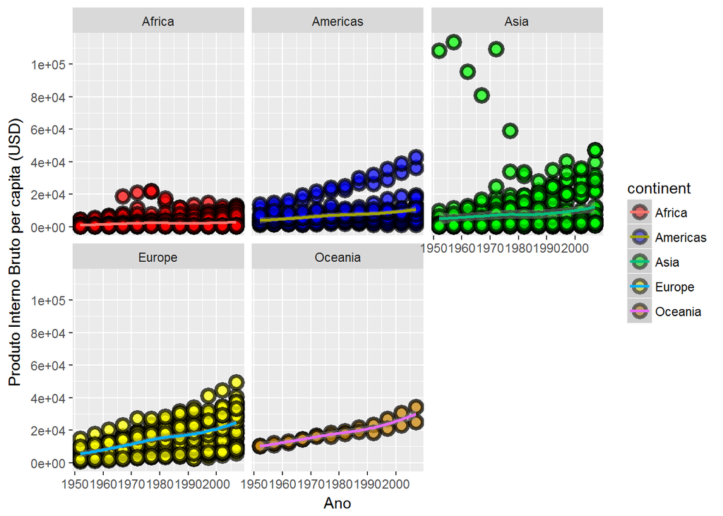

```r
# geom_smooth adiciona uma linha de tendência da relação x contra y
# de acordo com os níveis dos fatores que tenham sido mapeados e um tipo
# de método estatístico - padrão 'loess'
figura +
  facet_wrap(~ continent) +
  geom_smooth(data = gapminder, mapping = aes(x = year, y = gdpPercap, colour = continent))
```

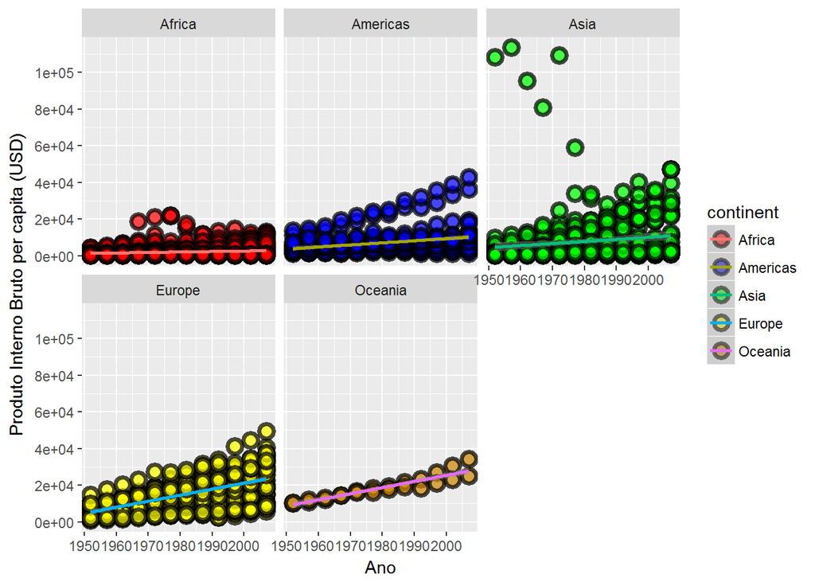

```r
# método lm
figura +
  facet_wrap(~ continent) +
  geom_smooth(data = gapminder, mapping = aes(x = year, y = gdpPercap, colour = continent),
              method = "lm")
```

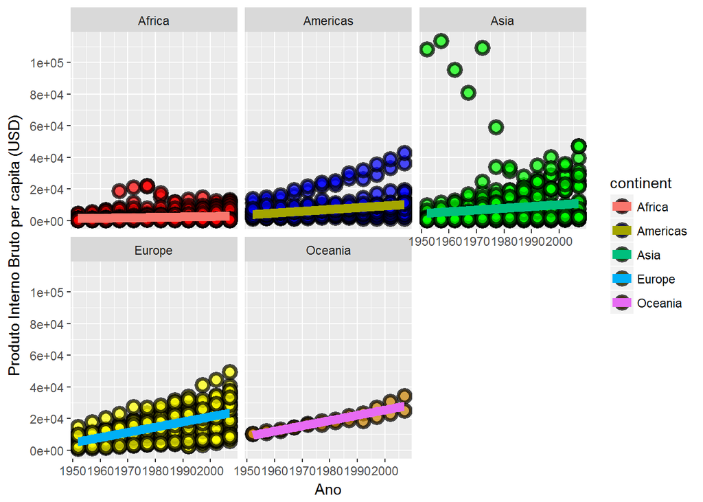

```r
# você pode modificar as opções de plotagem da linha de tendência direto no geom_smooth
figura +
  facet_wrap(~ continent) +
  geom_smooth(data = gapminder, mapping = aes(x = year, y = gdpPercap, colour = continent),
              method = "lm", size = 3, se = FALSE)
```

- **Dica do R:** aqui, cabe ressaltar três coisas muito importantes:
  - Cuidado ao usar o `geom_smooth`! Ao criar um modelo estatístico de regressão, ele **não** representa fielmente a relação entre a variável preditora (`x`) e a variável resposta (`y`) caso hajam outras variáveis preditoras na análise (inclusive a predição do intervalo de confiança). Portanto, não use o atalho de usar o `geom_smooth` para mostrar os resultados de uma análise que você fez em um trabalho, dissertação, tese ou artigo! A linha de tendência correta para ser usada é aquela que vem da função `predict` a partir das predições do seu modelo aplicadas a um novo conjunto de dados simulados;
  - O `ggplot` desenha os `geom` na ordem em que eles são adicionados. Nesse sentido, a ordem dos fatores altera o produto: e.g, plotar a linha de tendência e depois os pontos deixa os pontos mais visíveis *vs* plotar os pontos e depois a linha de tendência reforça a mensagem desta última;
  - Note que tivemos que especificar qual era o conjunto de dados que deveriam ser passados para o `geom_smooth`, apesar dos `geom_point` já “saber” a relação que estávamos trabalhando. Tivemos que fazer isso pois na chamada do `ggplot` havíamos criado um gráfico em branco, de forma que cada `geom` deve especificar o que ele plotará. Caso já tivéssemos anunciado na chamada do `ggplot` que iríamos plotar esta relação, não haveria a necessidade de repetirmos essa chamada no `geom_smooth`. Mais tarde iremos ver um exemplo em que misturar estas duas formas de criar gráficos também é possível.

##### Exercício 4

E se quiséssemos modificar o tipo de gráfico que queremos fazer e, por exemplo, fazer um `boxplot`?  
a. Faça um `boxplot` usando a função `ggplot`, mostrando de que forma o `gdpPercap` varia em função do `continent`;  
b. Modifique o preenchimento dos boxplots de acordo com a identidade do continente;  
c. Modifique a espessura e a largura da linha dos boxplots (dica: `size`e `width`);  
d. Suprima a plotagem dos outliers;  
e. Mude o título do eixo y;  
f. Edite o eixo x, de forma que:  
+ Ele tenha um novo título;  
+ As legendas de cada uma das categorias passe para o português.  
g. Adicione pontos que demonstrem os valores de cada observação para cada continente.

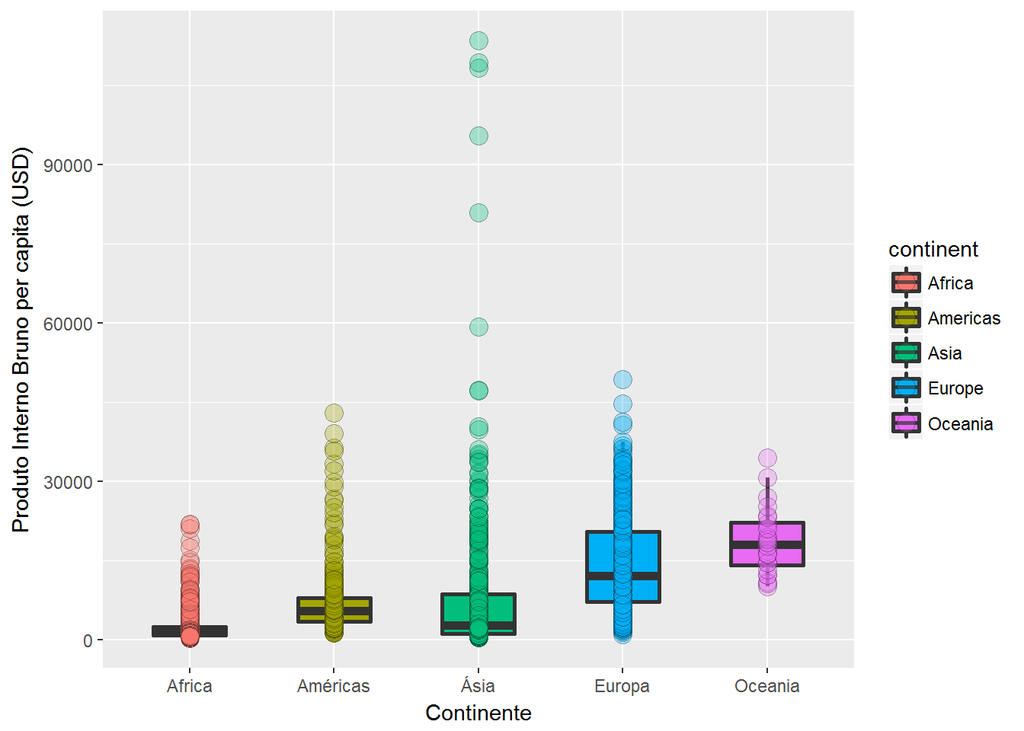

- **Dica do R:** têm três coisas aqui que pode ser útil de você saber:
1. **Sobreposição dos pontos:** o argumento `position` serve para modificar a posição relativa de algo que tenha sido plotado. Este argumento leva uma função que determina como esta sobreposição será trabalhada - alguns exemplos:
   - `position_jitter`: adiciona um pequeno ruído na horizontal e/ou vertical para reduzir a sobreposição;
   - `position_dodge`: reduz sobreposição na horizontal, mas fixa a vertical;
   - `position_jitterdodge`: útil para reduzir sobreposição da plotagem conjunta de pontos e boxplot;
   - `position_stack`: para empilhar barras em um gráfico de barras.

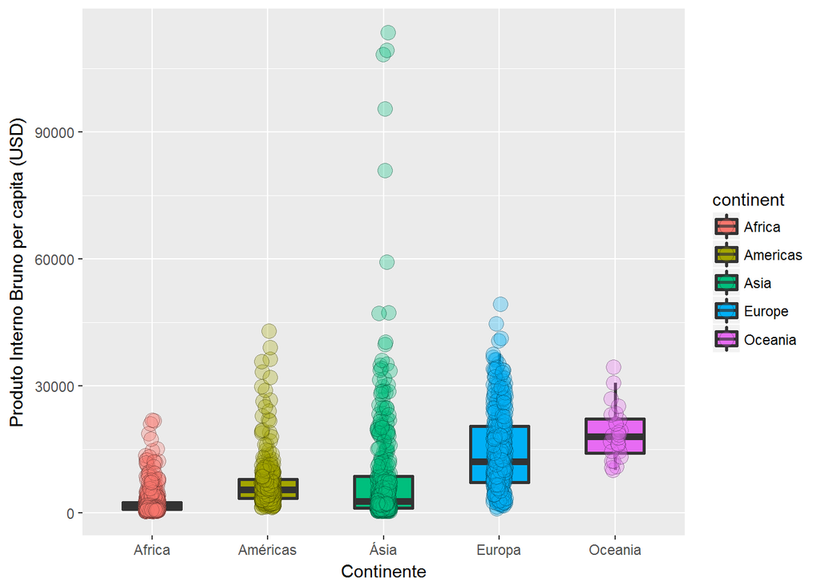

```r
ggplot(data = gapminder, mapping = aes(x = continent, y = gdpPercap, fill = continent)) +
  geom_boxplot(outlier.colour = NA, width = 0.5, size = 1) +
  scale_y_continuous(name = "Produto Interno Bruno per capita (USD)") +
  scale_x_discrete(name = "Continente", labels = c("Africa", "Américas", "Ásia", "Europa", "Oceania")) +
  geom_point(shape = 21, alpha = 0.3, size = 4, position = position_jitterdodge(dodge.width = 1))
```

2. **Eixo secundário:** a partir da última atualização do `ggplot2` agora fica mais fácil plotar informações em um eixo secundário através do argumento `sec.axis` dentro da função `scale_y_?`, principalmente quando (a) o eixo secundário é uma duplicação do eixo y primário ou (b) quando o eixo secundário é uma transformação dos valores do eixo primário. Para tal, você deve especificar uma de duas funções no argumento `sec.axis`:
   - `sec.axis = dup_axis()`, se a sua intenção é duplicar os valores do eixo primário no eixo secundário;
   - `sec.axis = sec_axis`, se a sua intenção é adicionar uma transformação dos valores do eixo primário no eixo secundário (ou algo similar).

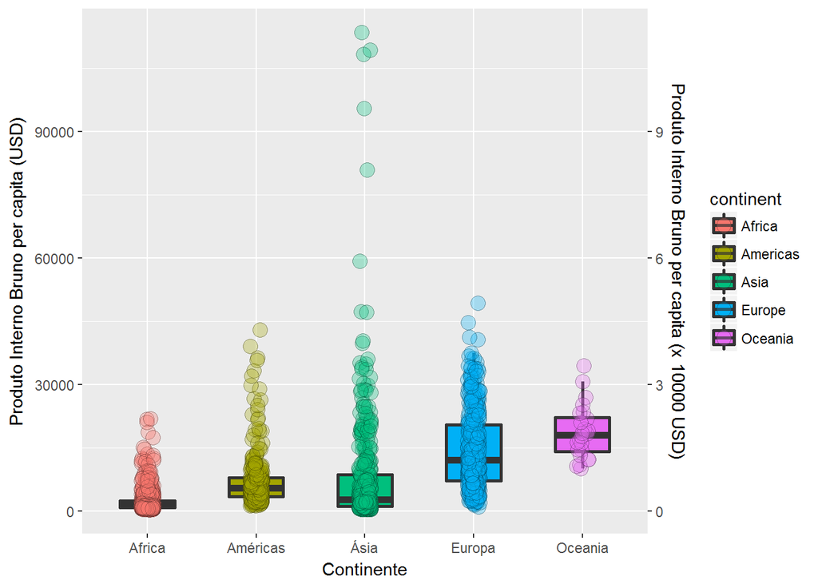

```r
ggplot(data = gapminder, mapping = aes(x = continent, y = gdpPercap, fill = continent)) +
  geom_boxplot(outlier.colour = NA, width = 0.5, size = 1) +
  scale_x_discrete(name = "Continente", labels = c("Africa", "Américas", "Ásia", "Europa", "Oceania")) +
  geom_point(shape = 21, alpha = 0.3, size = 4, position = position_jitterdodge(dodge.width = 1)) +
  scale_y_continuous(name = "Produto Interno Bruno per capita (USD)",
                     sec.axis = sec_axis(name = "Produto Interno Bruno per capita (x 10000 USD)",
                                         trans = ~ ./10000))
```

3. **Reordenar categorias:** como vimos, o R ordena os níveis de um fator de acordo com a ordem alfabética. No geral, isso não é muito um problema - até chegarmos à plotagem de gráficos. No entanto, existem dois “truques” que podemos usar para colocar o eixo x de um gráfico com variáveis discretas na ordem que queremos:
   - **Quando o objetivo é colocar os fatores em ordem decrescente da resposta:**

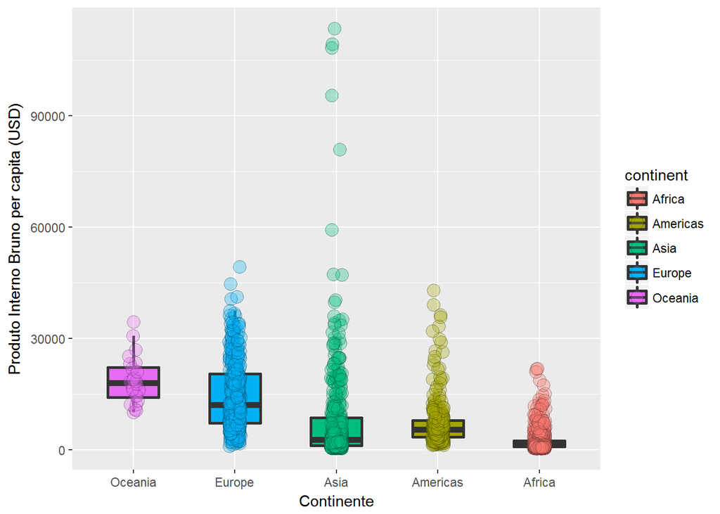

```r
ggplot(data = gapminder, mapping = aes(x = reorder(continent, -gdpPercap), y = gdpPercap, fill = continent)) +
  geom_boxplot(outlier.colour = NA, width = 0.5, size = 1) +
  scale_y_continuous(name = "Produto Interno Bruno per capita (USD)") +
  scale_x_discrete(name = "Continente") +
  geom_point(shape = 21, alpha = 0.3, size = 4, position = position_jitterdodge(dodge.width = 1))
```

- Alternativamente, você pode manipular o fator (variável discreta) usando as funções do pacote `forcats` - um pacote especialmente feito para lidar com variáveis que correspondem a este tipo de objeto:

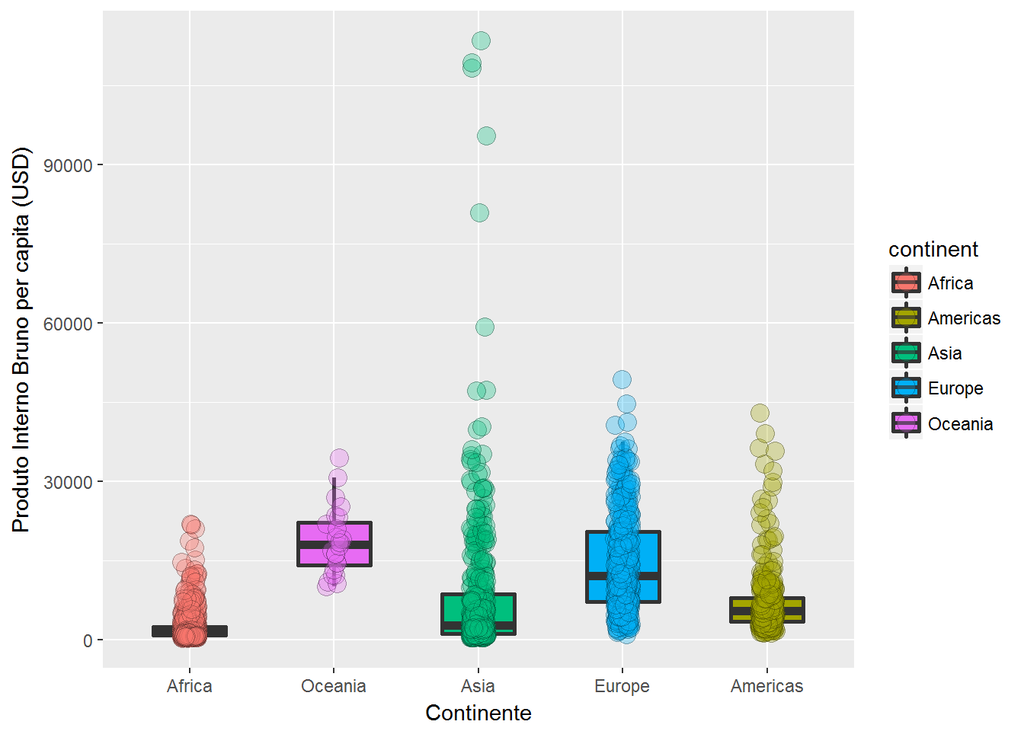

```r
ggplot(data = gapminder,
       mapping = aes(x = forcats::fct_relevel(continent, "Africa", "Oceania", "Asia", "Europe", "Americas"),
                                       y = gdpPercap, fill = continent)) +
  geom_boxplot(outlier.colour = NA, width = 0.5, size = 1) +
  scale_y_continuous(name = "Produto Interno Bruno per capita (USD)") +
  scale_x_discrete(name = "Continente") +
  geom_point(shape = 21, alpha = 0.3, size = 4, position = position_jitterdodge(dodge.width = 1))
```

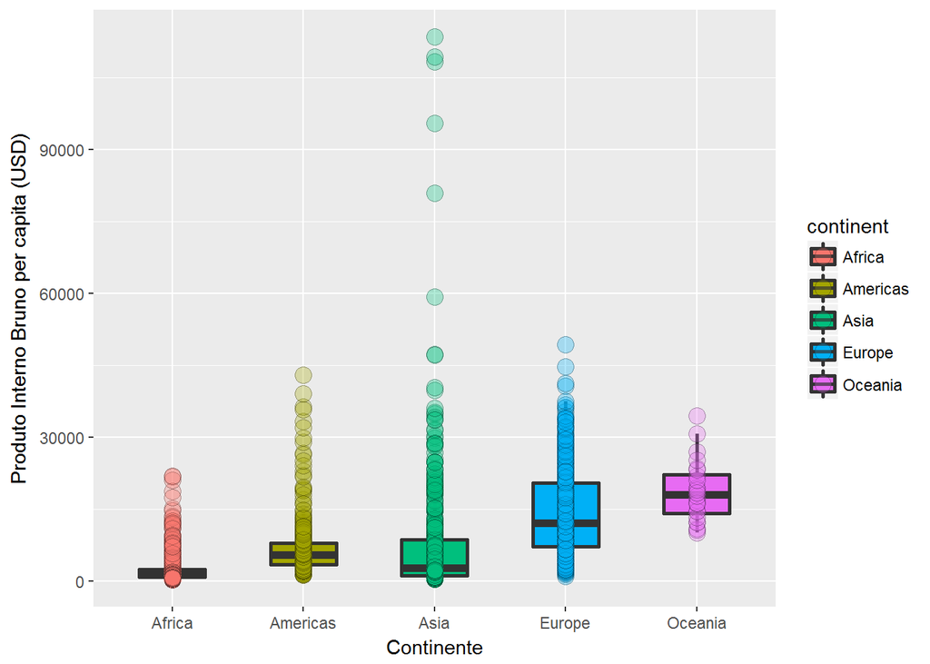

```r
# versão do gráfico para prosseguirmos
figura <- ggplot(data = gapminder, mapping = aes(x = continent, y = gdpPercap, fill = continent)) +
  geom_boxplot(outlier.colour = NA, width = 0.5, size = 1) +
  scale_y_continuous(name = "Produto Interno Bruno per capita (USD)") +
  scale_x_discrete(name = "Continente") +
  geom_point(shape = 21, alpha = 0.3, size = 4)
figura
```

O `ggplot2` fornece grande versatilidade e facilidade de plotagem, como temos visto até aqui. No entanto, é muito comum encontrarmos gráficos que têm essa cara do padrão do `ggplot`. Apesar de não haver nada errado com isso, muitas vezes não é tão “agradável” assim usar este padrão, seja por conta do fundo cinza (horroroso), seja através dessas linhas de grade, ou até mesmo pela cor e tamanho das fontes. Por conta disso, devemos sempre modificar o `theme` de um gráfico que estamos criando no `ggplot`.

Existem alguns `theme` já pré-editados disponíveis no `ggplot2` e no pacote `ggthemes`.

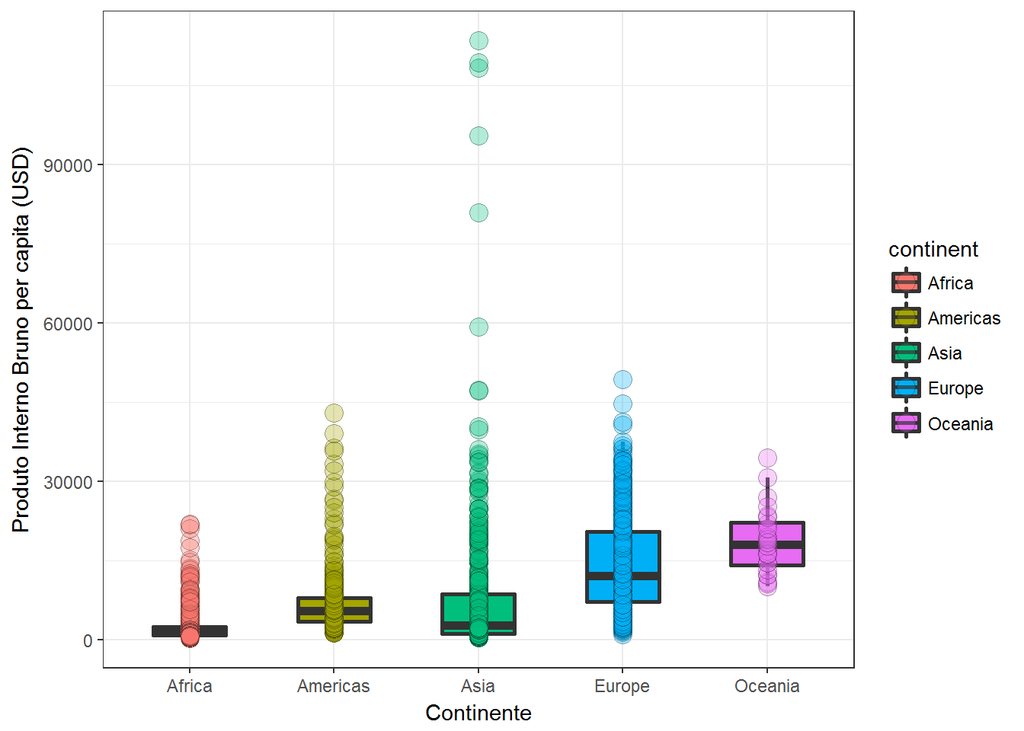

```r
# tema em preto e branco
figura +
  theme_bw()
```

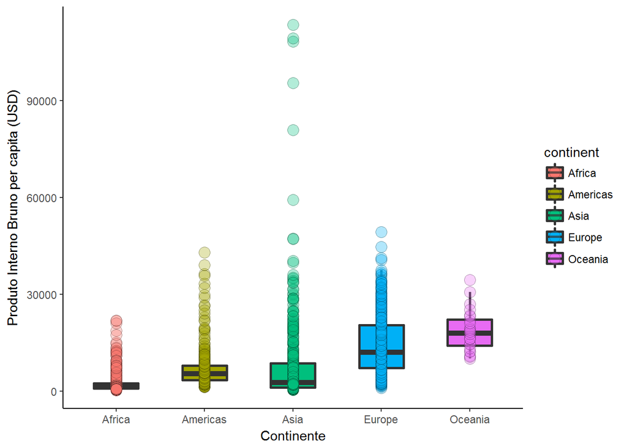

```r
# formato mais clássico de um gráfico
figura +
  theme_classic()
```